# Analyse de viabilité de population de la situation du Chevalier Cuivré (*Moxostoma hubbsi*) en utilisant une matrice de Lefkovitch à 3 stades

Tristan Plasse & Yohan Wegener

Abstract

Ce travail s’inscrit dans la continuité des recherches portant sur l’état de la population du Chevalier cuivré (Moxostoma hubbsi), une espèce endémique du Québec et désignée comme menacée. Alors que des estimations stochastiques fondées sur des matrices de Leslie à 33 stades ont été réalisées par Bannester-Marchand et al. (2025), la présente étude propose un modèle de matrice de Lefkovitch à trois stades. L’objectif est d’évaluer la capacité d’une méthode simplifiée à produire des résultats comparables en termes de précision. Les analyses démontrent que cette approche simplifiée s’avère concluante, les résultats obtenus suivent des tendances similaires que ceux documentés précédemment. Par contre, les résultats du modèle à 3 stades sont plus pessimistes. Par conséquent, une approche plus alarmiste devrait potentiellement être adoptée.

Le Chevalier cuivré (*Moxostoma hubbsi*) est une espèce de poisson d’eau douce endémique du Québec, au Canada. Sa distribution étant restreinte à certains secteurs du fleuve Saint-Laurent et de la rivière Richelieu, sa population est désignée comme en voie de disparition. La dégradation et la perte d’habitat en sont les causes principales (COSEPAC, 2014). À ce jour, seules deux frayères sont connues, et peu de mesures concrètes sont mises en place pour assurer leur préservation à perpétuité (COSEPAC, 2014).

Actuellement, des ensemencements sont effectués chaque année afin de maintenir une population viable. Plus de 14 000 larves et 230 000 alevins sont ainsi ensemencés dans la rivière Richelieu pour pallier le taux de recrutement très faible (COSEPAC, 2014). L’une des principales difficultés liées à la conservation de cette espèce réside dans le manque de connaissances biologiques sur ses traits d’histoire de vie. Une étude a récemment été réalisée pour estimer la viabilité à long terme de la population selon trois scénarios distincts reflétant la situation actuelle de l’espèce (Bannester-Marchand et al., 2025). Cette recherche a utilisé un modèle de matrice de Leslie à 33 stades pour réaliser une analyse de viabilité de population (PVA) et évaluer l’effet des ensemencements à long terme sur la population. L’objectif de la présente étude est de reproduire ces analyses en développant un modèle simplifié basé sur une matrice de Lefkovitch à 3 stades seulement.

# Méthodologie

### Données

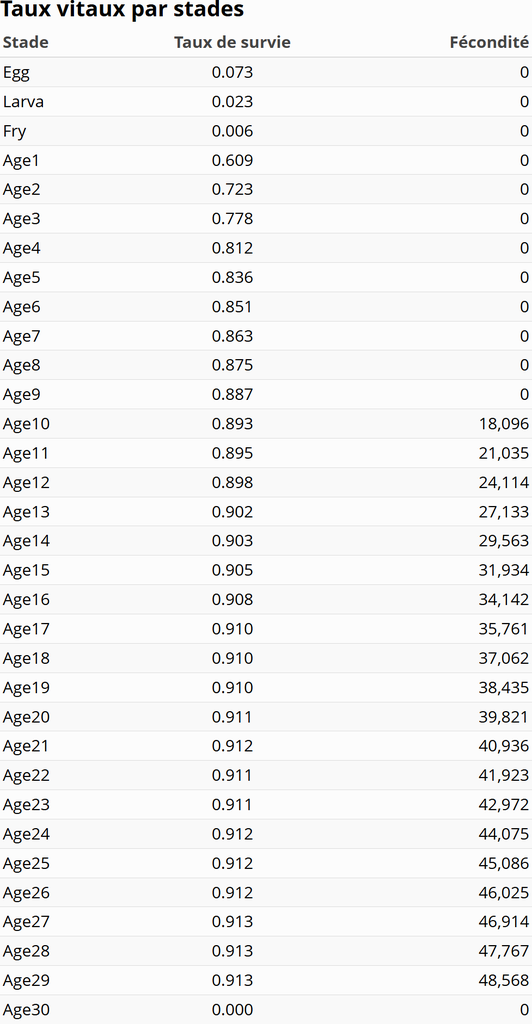

**Tableau 1 : Données utilisées pour la matrice mesurée.** Sont représentés : le stade, le taux de survie (valeur de la sous-diagonale de la matrice de Leslie) et la fécondité (valeur de la première rangée de la matrice de Leslie)

### Agrégation

Afin de préserver les dynamiques d’élasticité du modèle original, nous avons appliqué la méthode d’agrégation décrite par Hinrichsen et al. (2026). La dynamique initiale est formulée sous forme matricielle :

$$x(t+1) = Ax(t)$$

où $x(t)$ est la distribution des individus par classe d’âge au temps $t$ et $A$ est la matrice de Leslie ($n \times n$). La projection vers la structure agrégée $y(t)$ repose sur une matrice de partition $P$ ($m \times n$) :

$$y(t) = Px(t)$$
La matrice agrégée $\hat{B}$ ($m \times m$) est ensuite construite selon :

$$\hat{B} = PA^kQ$$

où $k$ représente le temps de résidence dans le stade et $Q$ est une matrice de poids d’agrégation définie par :

$$Q = WP^\top(PWP^\top)^{-1}$$
où $W = \text{diag}(w)$ correspond à la distribution stable des âges (vecteur propre dominant de $A$). Cette approche permet de conserver le taux de croissance asymptotique $\lambda$ ainsi que les propriétés de sensibilité du modèle initial (Hinrichsen, 2023).

### Stochasticité et Variabilité

Pour les taux de survie, nous avons suivi la méthode de Bannester-Marchand et al. (2025) en utilisant une distribution bêta. Le paramètre $\alpha$ est défini comme suit :
$$\frac{s_{stade} \times \beta}{1 - s_{stade}}$$
où $s_{stade}$ est la survie du stade et $\beta$ représente la variabilité. Nous avons sélectionné les valeurs de Bannester-Marchand et al. (2025) offrant la plus grande variabilité, soit $\beta = 5,05$ pour les Juvéniles et $\beta = 0,75$ pour les Pré-adultes. Pour les probabilités de rester dans un stade, les valeurs de $\beta$ ont été ajustées (1 et 0,75) afin d’assurer que la somme de la survie et de la stase demeure biologiquement cohérente (inférieure ou égale à 1).

### Modélisation

Le modèle de viabilité des populations (PVA) a été simulé sur $N = 5000$ itérations pour une période de $t = 100$ ans. La probabilité d’extinction est définie par l’atteinte d’une abondance nulle :

$$P_{ext} = P(\exists t \in [0, 100] : n_{total}(t) = 0)$$
Nous avons également évalué la probabilité que l’abondance des individus matures ($n_{mat}$) se maintienne au-dessus de seuils critiques $k$ (0 et 1000 individus) pour favoriser la diversité génétique :

$$P(n_{mat}(t) > k), \quad \forall t \in [0, 100] \text{ où } k \in
\{0, 1000\}$$
Enfin, nous avons testé l’efficacité des ensemencements pour atteindre une cible de 5000 individus matures. Bien que l’analyse utilise la matrice agrégée à trois stades, les taux de survie spécifiques aux stades ensemencés (larves, alevins, individus d’un an et de dix ans) ont été maintenus identiques à ceux de Bannester-Marchand et al. (2025) pour garantir la comparabilité des stratégies d’intervention.

# Résultats

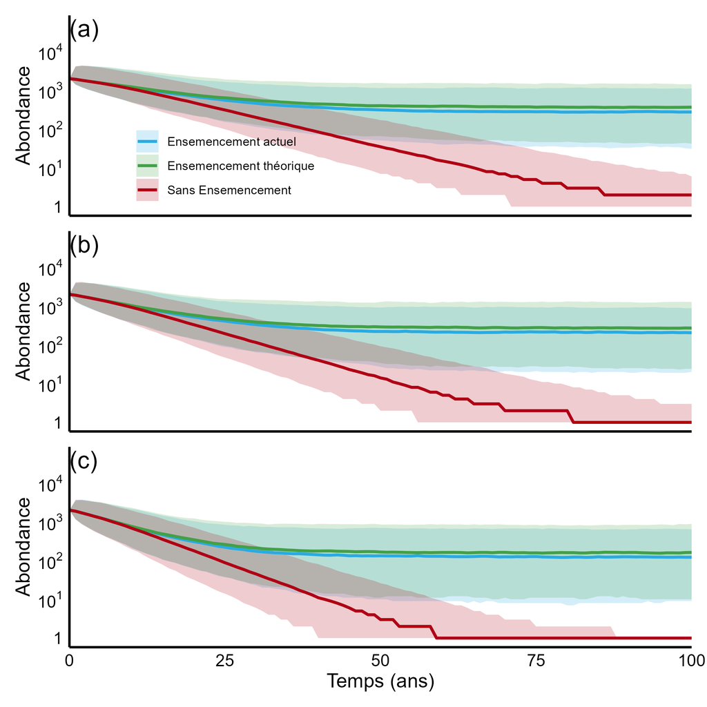

**Figure 1 : Abondance médiane du Chevalier cuivré selon le scéénario.** Est représenté : Abondance médiane de chevaliers cuivrés, basée sur 5000 itérations stochastiques pour les scénarios (a) nul, (b) menacé, (c) mesuré de notre modèle dynamique. Les enveloppes colorées représentent les intervalles de confiance à 95% ; les lignes pleines les abondances médianes d’individus matures.

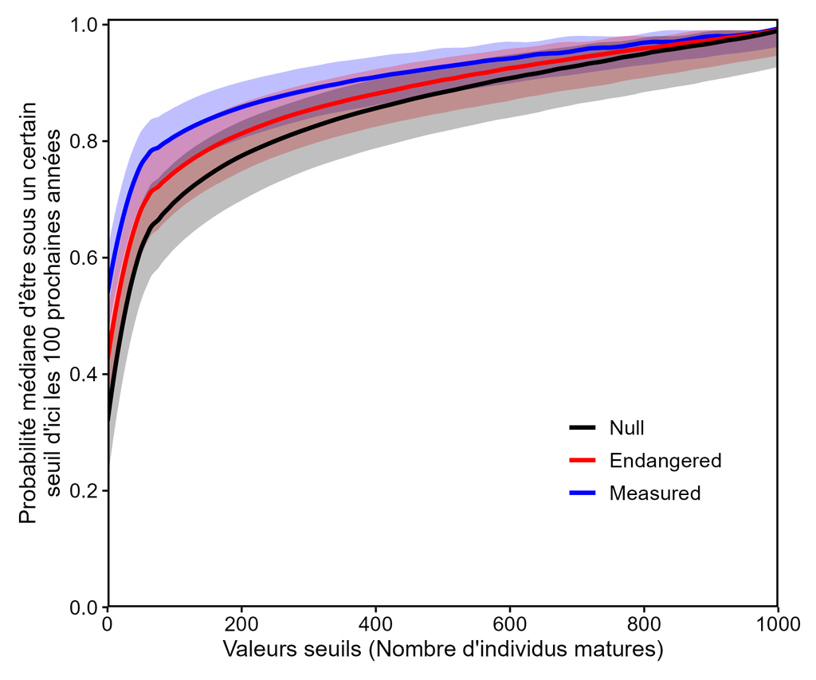

**Figure 2 : Probabilité d’être sous le seuil déterminé.** Est représenté : Les probabilités que les chevaliers cuivrés tombent sous un seuil de population dans les prochaines 100 ans, basé sur nos scénarios dynamique stochastiques de population. Lignes : médiane de 5000 itérations; enveloppes colorées : 70% ICs

Les probabilités de passer sous des seuils critiques augmentent rapidement (Figure 2). La probabilité que la population mature chute sous la barre des 1000 individus devient élevée dans tous les scénarios, y compris pour le scénario « nul ». Ainsi, même sous les hypothèses les plus optimistes, le maintien d’une population viable à long terme apparaît peu probable sans intervention majeure.

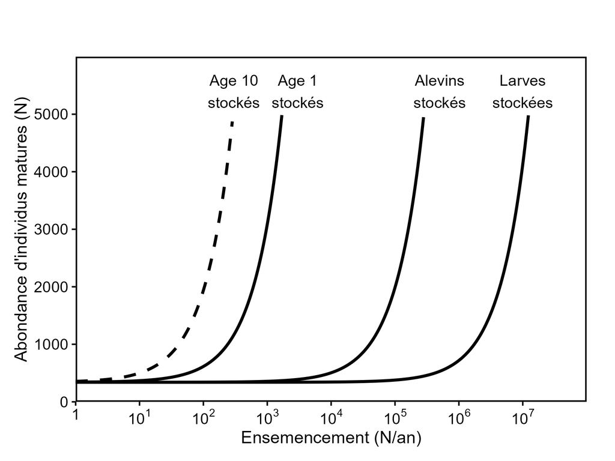

**Figure 3 : Ensemencement nécessaire pour atteindre 5000 individus matures.** Est représenté : L’effet d’augmenter l’ensemencement de larves, alevins, individus d’âges 1, et individus matures (âge 10) sur l’abondance de chevaliers matures sur 100 ans dans notre scénario mesuré.

Les simulations d’ensemencement révèlent que des apports massifs sont nécessaires pour atteindre une cible de 5000 individus matures après un siècle.Si l’augmentation du nombre d’individus introduits accroît l’abondance finale, cette relation n’est pas proportionnelle. Notamment, les ensemencements réalisés à des stades de vie plus avancés (individus d’un an ou matures) présentent une efficacité nettement supérieure à ceux effectués aux stades larvaires ou d’alevins (Figure 3).

# Discussion

Cette divergence s’explique probablement par la simplification structurelle du modèle. Le passage de 33 stades à seulement trois entraîne une perte substantielle d’information sur les transitions entre les classes d’âge. Bien que la méthode d’agrégation utilisée permette de conserver certaines propriétés asymptotiques, comme le taux de croissance ($\lambda$), elle ne capture pas nécessairement les dynamiques transitoires à court et moyen terme. Or, ces dynamiques sont cruciales dans une analyse de viabilité des populations (PVA), particulièrement lorsque l’effectif est faible et sensible aux fluctuations.

Le traitement de la stochasticité peut aussi expliquer les différences observées. Dans notre modèle, la fécondité varie de façon synchrone pour l’ensemble des adultes, alors que Bannester-Marchand et al. (2025) appliquaient une variabilité indépendante entre les classes d’âge. Ce choix amplifie les fluctuations annuelles : concrètement, une année environnementale défavorable affecte simultanément tous les reproducteurs, ce qui peut accélérer le déclin démographique. À cet égard, il serait pertinent de tester différentes approches de modélisation de la stochasticité. L’absence de consensus dans la littérature sur la méthode optimale pour combiner les variabilités inter-stades lors d’une agrégation constitue une limite ici explorée ; une paramétrisation plus fine, appuyée par une expertise accrue en dynamique stochastique, permettrait potentiellement de converger davantage vers les résultats du modèle détaillé.

Les résultats obtenus montrent également que l’ensemencement, tel qu’il est modélisé ici, ne suffit pas à assurer la viabilité de la population. L’augmentation du nombre de larves ou d’alevins n’a pas l’impact escompté sur l’abondance des adultes à long terme. Cela souligne le rôle critique des stades juvéniles et pré-adultes : si la survie à ces étapes de vie est trop faible, le recrutement vers le stade adulte demeure insuffisant, quel que soit l’effort d’introduction initial. Par conséquent, des mesures visant à améliorer les conditions de survie (restauration de l’habitat, qualité de l’eau, accès aux frayères) pourraient s’avérer plus efficaces qu’une simple intensification des ensemencements.

Malgré ces différences, les tendances générales demeurent cohérentes avec les connaissances actuelles sur l’espèce. La population reste extrêmement vulnérable et dépendante des interventions humaines. La difficulté à maintenir une population stable sans soutien artificiel confirme le statut précaire du Chevalier cuivré.

En conclusion, cette étude met en évidence les limites inhérentes aux modèles simplifiés. Si la matrice de Lefkovitch à trois stades est plus parcimonieuse et exige moins de données, elle introduit des biais importants qui, dans ce cas précis, semblent accentuer le déclin de la population. Bien que ce type de modèle soit utile pour explorer rapidement divers scénarios, il doit être utilisé avec prudence. Pour des analyses de viabilité plus précises, le maintien d’une structure d’âge détaillée demeure essentiel.

# Bibliographie

Bannester-Marchand, N., Vachon, N., Mandrak, N. et Blanchet, F. (2025). Population viability analysis of the endangered copper redhorse *Moxostoma hubbsi*. *Endangered Species Research*, *57*, 21‑31. https://doi.org/10.3354/esr01395

COSEPAC. (2014). Évaluation et Rapport de situation du COSEPAC sur le chevalier cuivré (*Moxostoma hubbsi*) au Canada. *Comité sur la situation des espèces en péril au Canada*, xiii + 81. https://wildlife-species.canada.ca/species-risk-registry/virtual_sara/files/cosewic/sr_Copper%20Redhorse_2014_f.pdf

Dahlberg, M. D. (1979). A review of survival rates of fish eggs and larvae in relation to impact assessments. *Marine Fisheries Review*, *41*(3).

Hinrichsen, R. A. (2023). Aggregation of Leslie matrix models with application to ten diverse animal species. *Population Ecology*, *65*(3), 146‑166. https://doi.org/10.1002/1438-390X.12149

Hinrichsen, R. A., Yokomizo, H. et Salguero-Gómez, R. (2026, février). From theory to application: Elasticity-consistent aggregation of Leslie matrix population models for comparative demography. bioRxiv. https://doi.org/10.64898/2026.02.04.703802

Mongeau, J.-R., Dumont, P. et Cloutier, L. (1986). *La biologie du Suceur cuivré, *Moxostoma hubbsi*, une espèce rare et endémique à la région de Montréal, Québec, Canada*. https://portals.iucn.org/library/node/15279

Mongeau, J.-R., Dumont, P. et Cloutier, L. (1992). La biologie du suceur cuivré (*Moxostoma hubbsi*) comparée à celle de quatre autres espèces de *Moxostoma* (*M. anisurum, M. carinatum, M. macrolepidotum* et *M. valenciennesi*). *Canadian Journal of Zoology*, *70*(7), 1354‑1363. https://doi.org/10.1139/z92-191

Vachon, N. (2020). *Recherche de subadultes du chevalier cuivré et suivi du recrutement en 2016*. https://doi.org/10.13140/RG.2.2.33614.79689

Vachon, N. (2021a). *Reproduction artificielle, ensemencements et suivi de la population du chevalier cuivré (*Moxostoma hubbsi*) en 2018*.

Vachon, N. (2021b). *Reproduction artificielle, ensemencements et suivi de la population du chevalier cuivré (*Moxostoma hubbsi*) en 2019*. https://www.researchgate.net/publication/356970163_Reproduction_artificielle_ensemencements_et_suivi_de_la_population_du_chevalier_cuivre_Moxostoma_hubbsi_en_2019